# Informe AEMET

### 1. Elegir conjunto de datos

La primera parte de la actvidad consta en elegir un conjunto de datos de la AEMET que abarque más de un mes.

Lo primero que vamos a hacer es cargar la API KEY que nos proporcionó la AEMET por correo electrónico

```python
API_KEY="eyJhbGciOiJIUzI1NiJ9.eyJzdWIiOiJyYXF1ZWxmZXJ2ZWxAZ21haWwuY29tIiwianRpIjoiYzMzMjgw….NpSLVBOls3r5s6gVyfqIHhzQ0RRjl9zQhhXqju3rWas"
```

Y posteriormente vamos a cargar los paquetes necesarios para las posteriores ejecuciones de los comandos

```python
import numpy as np
import requests
import pandas as pd
import pprint
from datetime import datetime, timedelta
import matplotlib.pyplot as plt #Graficos
```

Ahora que ya tenemos la API cargada y los paquetes necesarios también vamos a elegir una base de datos. Nuestra base de datos abarca del 1 de Enero al 31 de Diciembre del año 2023 (365 días)

```python
# Definir fechas de inicio y fin del periodo general
fecha_inicio_str = "2023-01-01T00:00:00UTC"
fecha_fin_str = "2023-12-31T00:00:00UTC"

# Convertir las fechas de texto a objetos datetime porque el while necesita las fechas en formato "datetime" para poder compararlas
fecha_inicio = datetime.strptime(fecha_inicio_str, "%Y-%m-%dT%H:%M:%SUTC")
fecha_fin = datetime.strptime(fecha_fin_str, "%Y-%m-%dT%H:%M:%SUTC")

# DataFrame para almacenar resultados
df_datos = pd.DataFrame()

# Iterar en intervalos de 15 días
while fecha_inicio < fecha_fin:
    # Calcular el intervalo de fechas
    fecha_intervalo = fecha_inicio + timedelta(days=15)
    if fecha_intervalo > fecha_fin:  # Asegurarse de no exceder la fecha final
        fecha_intervalo = fecha_fin

    # Convertir las fechas a cadenas de texto para la URL
    fecha_inicio_str = fecha_inicio.strftime("%Y-%m-%dT%H:%M:%SUTC")
    fecha_intervalo_str = fecha_intervalo.strftime("%Y-%m-%dT%H:%M:%SUTC")

    # Construir la URL
    url = f"https://opendata.aemet.es/opendata/api/valores/climatologicos/diarios/datos/fechaini/{fecha_inicio_str}/fechafin/{fecha_intervalo_str}/todasestaciones?api_key={API_KEY}"

    # Realizar la solicitud
    response = requests.get(url)
    if response.status_code == 200:
        data_url = response.json().get("datos")
        if data_url:
            response_data = requests.get(data_url)
            if response_data.status_code == 200:
                datos_json = response_data.json()
                # Agregar los datos al DataFrame
                df_temp = pd.json_normalize(datos_json)
                df_datos = pd.concat([df_datos, df_temp], ignore_index=True)

    # Actualizar la fecha de inicio al siguiente intervalo
    fecha_inicio = fecha_intervalo
```

```python
df_datos.info() #una pequeña descripción de los datos
```

```
<class 'pandas.core.frame.DataFrame'>
RangeIndex: 341638 entries, 0 to 341637
Data columns (total 25 columns):
 #   Column       Non-Null Count   Dtype
---  ------       --------------   -----
 0   fecha        341638 non-null  object
 1   indicativo   341638 non-null  object
 2   nombre       341638 non-null  object
 3   provincia    341638 non-null  object
 4   altitud      341638 non-null  object
 5   tmed         334568 non-null  object
 6   prec         331770 non-null  object
 7   tmin         334651 non-null  object
 8   horatmin     332981 non-null  object
 9   tmax         334684 non-null  object
```

[output cut: 17 more lines]

### 2. Narrativa

Creamos una narrativa que sirva como hilo conductor del análisis.  
Nuestra narrativa va a ser:

Promotor de turismo en Asturias: Demostrar que la región tiene menos días de lluvia de lo que se piensa comúnmente

```python
# Filtramos el data frame por la provincia que nos interesa (Asturias)
# y creamos una copia para no modificar el data frame original
df_asturias= df_datos[df_datos["provincia"] == "ASTURIAS"].copy()
```

```python
# Lo renombramos para tener un nombre corto y volvemod a crear una copia explícita del DataFrame porque sino en el futuro da errores del tipo "SettingWithCopyWarning"
df = df_asturias.copy()
```

### 3. Análisis de los datos

La tercera parte consiste en analizar los datos utilizando Python. Se deberán aplicar técnicas de limpieza, manipulación y consulta de datos.

#### 3.1. Limpieza de datos:

Lo primero puede ser detectar columnas con valores nulos o datos incompletos

```python
df.isnull().sum() # Detecta columnas con valores nulos
```

```
fecha             0
indicativo        0
nombre            0
provincia         0
altitud           0
tmed             68
prec            141
tmin             68
horatmin         79
tmax             68
horatmax         72
hrMax            96
horaHrMax        96
hrMin            96
horaHrMin        96
hrMedia         104
dir             577
velmedia        529
racha           577
horaracha       577
presMax        6566
horaPresMax    6566
presMin        6567
horaPresMin    6567
sol            7224
dtype: int64
```

```python
df.shape # Dimensiones del data frame (9377 observaciones y 25 columnas)
```

```
(9377, 25)
```

```python
# Porcentaje de nulos en la varibale "prec"
porcentaje_nulos = (141 / 9377) * 100
print(porcentaje_nulos)
```

```
1.5036792151007785
```

Dado que el porcentaje de nulos es bajo (1.5%) y como la variable “prec” es clave para la narrativa, eliminar las filas con valores nulos parece la mejor opción para evitar sesgos.

```python
df = df.dropna(subset=['prec'])
```

```python
df.isnull().sum() # Verificamos que en la variable "prec" hay 0 datos nulos
```

```
fecha             0
indicativo        0
nombre            0
provincia         0
altitud           0
tmed             36
prec              0
tmin             36
horatmin         47
tmax             36
horatmax         39
hrMax            64
horaHrMax        64
hrMin            64
horaHrMin        64
hrMedia          99
dir             535
velmedia        511
racha           535
horaracha       535
presMax        6486
horaPresMax    6486
presMin        6487
horaPresMin    6487
sol            7126
dtype: int64
```

Otra forma de depurar los datos puede ser cambiando el formato de algunas varibales como la fecha que cambiamos el formato de “objeto” a formato “datetime”. Tambien convertimos algunas variables a numéricas como pueden ser las temperaturas, las precipitaciones y las horas de luz.

```python
# Establecer tipos de datos:

# Convierte las columnas a los tipos adecuados, especialmente las fechas y valores numéricos:
df['fecha'] = pd.to_datetime(df['fecha'])

# Reemplazar comas por puntos en las columnas numéricas
columnas_a_convertir = ['tmed', 'prec', 'tmin', 'tmax','sol']
for columna in columnas_a_convertir:
    df[columna] = pd.to_numeric(df[columna].str.replace(',', '.'), errors='coerce')

# Cuando intentas convertir una columna de datos de cadenas (str) a números (float o int), algunos valores podrían no ser válidos (por ejemplo, texto o caracteres especiales).
# Con errors='coerce', pandas reemplaza esos valores no válidos con NaN.
```

```python
df.dtypes #verificamos si cambiamos el tipo de datos
```

```
fecha          datetime64[ns]
indicativo             object
nombre                 object
provincia              object
altitud                object
tmed                  float64
prec                  float64
tmin                  float64
horatmin               object
tmax                  float64
horatmax               object
hrMax                  object
horaHrMax              object
hrMin                  object
horaHrMin              object
hrMedia                object
dir                    object
velmedia               object
racha                  object
horaracha              object
presMax                object
horaPresMax            object
presMin                object
horaPresMin            object
sol                   float64
dtype: object
```

También podemos verificar valores inconsistentes

```python
# Verifica valores improbables, como precipitaciones negativas.
df[df['prec'] < 0]
```

|  | fecha | indicativo | nombre | provincia | altitud | tmed | prec | tmin | horatmin | tmax | ... | hrMedia | dir | velmedia | racha | horaracha | presMax | horaPresMax | presMin | horaPresMin | sol |
| --- | --- | --- | --- | --- | --- | --- | --- | --- | --- | --- | --- | --- | --- | --- | --- | --- | --- | --- | --- | --- | --- |

0 rows × 25 columns

#### 3.2. Manipulación de Datos

Puede ser definir un día como lluvioso

```python
# Crea una nueva columna que identifique días lluviosos (por ejemplo, si prec >= 1 mm/h):
df['es_lluvioso'] = df['prec'] >= 1
print(df)
```

```
            fecha indicativo                 nombre provincia altitud  tmed  \
32     2023-01-01      1212E    ASTURIAS AEROPUERTO  ASTURIAS     127  12.2
100    2023-01-01      1331A              CASTROPOL  ASTURIAS      40  11.6
107    2023-01-01      1234P          MIERES, BAIÑA  ASTURIAS     170  15.0
119    2023-01-01      1183X                 LLANES  ASTURIAS      10  17.6
158    2023-01-01      1279X          SALAS, CAMUÑO  ASTURIAS     240  11.4
...           ...        ...                    ...       ...     ...   ...
341524 2023-12-31      1327A        VILLAYÓN, ONETA  ASTURIAS     410   7.9
341535 2023-12-31      1203D                COLUNGA  ASTURIAS      30  11.4
341560 2023-12-31      1207U          GIJÓN, CAMPUS  ASTURIAS      26   NaN
341604 2023-12-31      1199X        PILOÑA, BARGAÉU  ASTURIAS     280   9.2
341617 2023-12-31       1542  PUERTO DE LEITARIEGOS  ASTURIAS    1530   0.4

        prec  tmin horatmin  tmax  ...  dir velmedia racha horaracha presMax  \
32       9.5  10.1    22:44  14.4  ...   26      3,1  12,8     22:36  1003,3
```

[output cut: 25 more lines]

También podemos crear agrupaciones para calcular el porcentaje de días lluviosos de cada mes:

```python
# Agrupaciones

# Calcula el porcentaje de días lluviosos en cada mes:
df['mes'] = df['fecha'].dt.month #Crea una nueva columna con los meses (1,...,12)
dias_lluviosos_por_mes = df.groupby('mes')['es_lluvioso'].mean() * 100
print(dias_lluviosos_por_mes)
```

```
mes
1     52.781371
2     18.468468
3     20.939086
4     24.313725
5     35.242839
6     37.582129
7     10.539216
8     30.223881
9     34.559790
10    46.194226
11    56.434316
12    40.581542
Name: es_lluvioso, dtype: float64
```

Obtener un resumen por ciudad de los días que llueve:

```python
resumen_ciudad = df.groupby('nombre')['es_lluvioso'].mean() * 100
print(resumen_ciudad)
```

```
nombre
ALLER, FELECHOSA                           32.368421
AMIEVA, PANIZALES                          34.278351
ASTURIAS AEROPUERTO                        34.190231
CABO BUSTO                                 30.219780
CABO PEÑAS                                 28.248588
CABRALES                                   34.491979
CASTROPOL                                  36.103896
COLUNGA                                    35.732648
DEGAÑA                                     37.878788
GIJÓN, CAMPUS                              32.311978
GIJÓN, PUERTO                              31.088083
IBIAS, SAN ANTOLIN                         35.989717
LENA, RONZÓN                               30.591260
LLANES                                     36.216216
MIERES, BAIÑA                              31.865285
OVIEDO                                     34.729064
PAJARES-VALGRANDE                          37.795276
PILOÑA, BARGAÉU                            35.218509
POLA DE SOMIEDO                            34.025974
PUERTO DE LEITARIEGOS                      29.565217
SALAS, CAMUÑO                              32.075472
SOTRES, PARQUE NACIONAL PICOS DE EUROPA    35.428571
TARAMUNDI, OURIA                           38.845144
TINEO, SOUTU                               32.731959
VILLAYÓN, ONETA                            37.336815
Name: es_lluvioso, dtype: float64
```

Duración del sol (Analiza los días con más horas de sol):

```python
# Definimos lo que es un día soleado en Asturias
dias_soleados = df[df['sol'] > 8]  # Por ejemplo, días con más de 8 horas de sol.

# Eliminar duplicados basados en la columna 'fecha' porque en el mismo día puede haber muchos lugares con más de 8 horas de sol
dias_soleados_unicos = dias_soleados.drop_duplicates(subset='fecha')

# Mostrar el resultado
print(dias_soleados_unicos.shape)
```

```
(190, 27)
```

Donde obtenemos 190 días soleados a lo largo de un año (un poco más de la mitad de los días)

Tendencias climáticas por mes

```python
# Precipitaciones (mm/h) en los diferentes meses
tendencias = df.groupby('mes')['prec'].mean()
tendencias
```

```
mes
1     9.170443
2     2.001955
3     1.012595
4     1.319554
5     1.969327
6     2.982914
7     0.346798
8     2.173908
9     2.454690
10    4.873553
11    5.302685
12    3.034684
Name: prec, dtype: float64
```

Tendencias climáticas por estaciones

```python
# Crear un mapa para asociar los meses con las estaciones
def asignar_estacion(mes):
    if mes in [12, 1, 2]:
        return 'Invierno'
    elif mes in [3, 4, 5]:
        return 'Primavera'
    elif mes in [6, 7, 8]:
        return 'Verano'
    else:  # [9, 10, 11]
        return 'Otoño'

# Aplicar la función al DataFrame
df['estacion'] = df['mes'].apply(asignar_estacion) #Crear una nueva columna llamada "estacion"

# Calcular la media de los días lluviosos por estación
lluvia_por_estacion = df.groupby('estacion')['es_lluvioso'].mean() * 100

print(lluvia_por_estacion)
```

```
estacion
Invierno     38.206278
Otoño        45.658881
Primavera    26.910017
Verano       25.829483
Name: es_lluvioso, dtype: float64
```

En Verano y Primavera aproximadamente solo llueve 1 de cada 4 días

#### 3.3. Consulta de datos

¿Qué porcentaje de días en el año son lluviosos?

```python
porcentaje_lluviosos = df['es_lluvioso'].mean() * 100
print(porcentaje_lluviosos)
```

```
33.96491987873539
```

¿Qué meses tienen menos lluvia?

```python
# Agrupar por mes y calcular la suma de precipitaciones
lluvia_mensual = df.groupby('mes')['prec'].sum()

# Ordenar de menor a mayor
lluvia_mensual_ordenada = lluvia_mensual.sort_values()

# Imprimir el resultado
print(lluvia_mensual_ordenada)
```

```
mes
7      281.6
3      795.9
4     1005.5
2     1331.3
5     1579.4
8     1741.3
9     1858.2
6     2252.1
12    2397.4
10    3703.9
11    3950.5
1     7042.9
Name: prec, dtype: float64
```

¿Cuáles son las ciudades con más mayores temperaturas?

```python
# Calcular la media por ciudad
temp_ciudad = df.groupby('nombre')['tmax'].mean()

# Ordenar de mayor a menor
temp_ciudad_ordenada = temp_ciudad.sort_values(ascending=False)

# Imprimir el resultado
print(temp_ciudad_ordenada)
```

```
nombre
MIERES, BAIÑA                              20.902073
AMIEVA, PANIZALES                          20.372280
SALAS, CAMUÑO                              20.371968
TINEO, SOUTU                               20.349485
GIJÓN, CAMPUS                              20.297740
PILOÑA, BARGAÉU                            20.107772
CASTROPOL                                  19.774805
LENA, RONZÓN                               19.762211
GIJÓN, PUERTO                              19.471244
CABRALES                                   19.252139
CABO BUSTO                                 19.203857
LLANES                                     19.189730
POLA DE SOMIEDO                            19.075584
COLUNGA                                    18.870437
CABO PEÑAS                                 18.767449
ASTURIAS AEROPUERTO                        18.617995
IBIAS, SAN ANTOLIN                         18.372751
OVIEDO                                     18.240741
ALLER, FELECHOSA                           17.963492
TARAMUNDI, OURIA                           17.811842
VILLAYÓN, ONETA                            17.266492
DEGAÑA                                     16.125915
SOTRES, PARQUE NACIONAL PICOS DE EUROPA    15.912000
PUERTO DE LEITARIEGOS                      14.128986
PAJARES-VALGRANDE                          11.909574
Name: tmax, dtype: float64
```

Compara los días lluviosos entre ciudades y meses:

```python
lluvia_ciudad_mes = df.groupby(['nombre', 'mes'])['es_lluvioso'].mean() * 100
print(lluvia_ciudad_mes)
```

```
nombre            mes
ALLER, FELECHOSA  1      48.484848
                  2      20.689655
                  3      12.121212
                  4      21.875000
                  5      52.941176
                           ...
VILLAYÓN, ONETA   8      40.000000
                  9      34.375000
                  10     57.575758
                  11     64.516129
                  12     48.484848
Name: es_lluvioso, Length: 294, dtype: float64
```

### 4. Graficos

Incluir al menos un gráfico que represente de forma efectiva la información relevante para su narrativa.

#### 4.1. Lluvia mensual

Gráfico de barras para mostrar el total de precipitación mensual

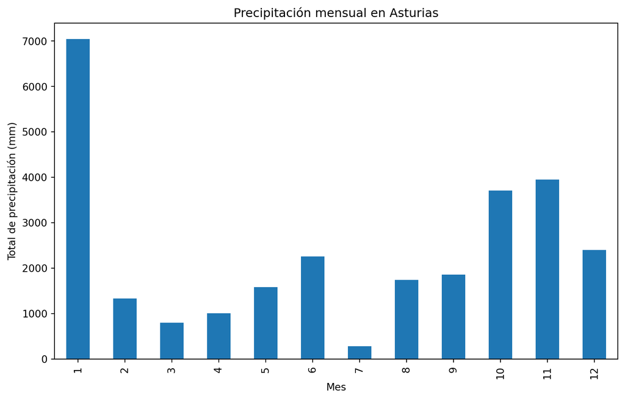

```python
lluvia_mensual.plot(kind='bar', figsize=(10, 6))
plt.title('Precipitación mensual en Asturias')
plt.xlabel('Mes')
plt.ylabel('Total de precipitación (mm)')
plt.show()
```

#### 4.2. Relación entre Precipitación y Horas de Sol

Un gráfico de dispersión que relacione la precipitación diaria (prec) con las horas de sol (sol) para evaluar si más precipitación tiende a coincidir con menos horas de sol.

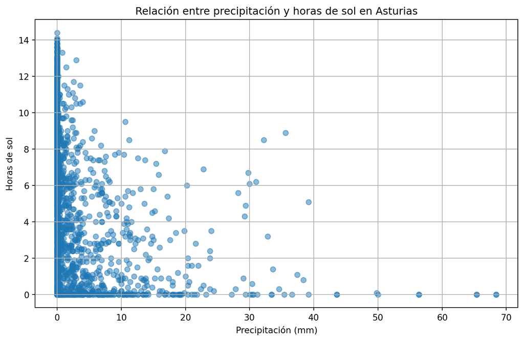

```python
# Crear gráfico de dispersión
plt.figure(figsize=(10, 6))
plt.scatter(df['prec'], df['sol'], alpha=0.5)
plt.title('Relación entre precipitación y horas de sol en Asturias')
plt.xlabel('Precipitación (mm)')
plt.ylabel('Horas de sol')
plt.grid()
plt.show()
```

¿Por qué es útil? Este gráfico visualiza la interacción entre días lluviosos y soleados, mostrando si la lluvia reduce significativamente las horas de sol.

#### 4.3. Horas de sol

Gráfico de líneas para mostrar la tendencia de las horas de sol por mes

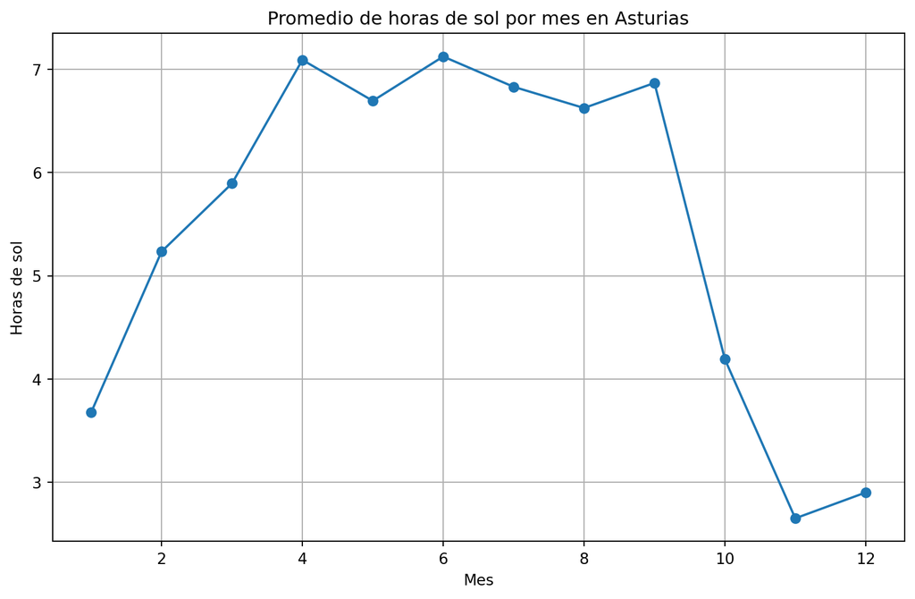

```python
horas_sol_mes = df.groupby('mes')['sol'].mean()
horas_sol_mes.plot(kind='line', marker='o', figsize=(10, 6))
plt.title('Promedio de horas de sol por mes en Asturias')
plt.xlabel('Mes')
plt.ylabel('Horas de sol')
plt.grid()
plt.show()
```

#### 4.4. Comparación de Temperaturas Mínimas, Medias y Máximas

Un gráfico de líneas para comparar las temperaturas mínimas (tmin), medias (tmed) y máximas (tmax) promedio por mes.

[figure not shown]

```python
# Agrupar por mes y calcular promedios
temperaturas_mes = df.groupby('mes')[['tmin', 'tmed', 'tmax']].mean()

# Crear gráfico de líneas
temperaturas_mes.plot(kind='line', figsize=(12, 6), marker='o')
plt.title('Temperaturas promedio por mes en Asturias')
plt.xlabel('Mes')
plt.ylabel('Temperatura (°C)')
plt.xticks(range(12), ['Ene', 'Feb', 'Mar', 'Abr', 'May', 'Jun', 'Jul', 'Ago', 'Sep', 'Oct', 'Nov', 'Dic'])
plt.grid()
plt.legend(['T. Mínima', 'T. Media', 'T. Máxima'])
plt.show()
```

En verano llueve poco y hace temperaturas moderadas (20ºC en Gijon) por lo que: Adeás de demostrar que no llueve tanto como parece (1 de cada 4 días en primavera y verano) se podrían realizar actividades deportivas en la playa en verano como Volley o incluso realizar alguna actividad para niños pequeños para que socilizen y hagan deporte mientras sus padres pueden disfrutar de un buen día de playa tranquilos. Por lo que podríamos decir que al final junté 2 narrativas como pueden ser la de demostrar que en Asturias no llueve tanto como parece y la de ser una empresa que que se dedica a la promoción de actividades.